# Problem 3

### Overview

You own a coffee shop and want to evaluate [coffee beans](https://en.wikipedia.org/wiki/Coffee_bean) sources. Your coffee shops buys both Arabica and the Robusta coffee beans from a coffee wholesaler that receives from all over the world.

Here are the breakdown of countries:

```r
library(scales)
country <- c('Vietnam','Brazil','Indonesia','Ethiopia','Columbia')
Arabica <- c(.4, .25, .2,.1,.05)
Robusta <- c(.1, .5, .1,.1,.2)
df <- data.frame(Country = country,
                 Arabica = percent(Arabica,.01),
                 Robusta = percent(Robusta,.01),
                 stringsAsFactors = FALSE)
library(knitr)
kable(df)
```

| Country | Arabica | Robusta |
| --- | --- | --- |
| Vietnam | 40.00% | 10.00% |
| Brazil | 25.00% | 50.00% |
| Indonesia | 20.00% | 10.00% |
| Ethiopia | 10.00% | 10.00% |
| Columbia | 5.00% | 20.00% |

Drinks with Arabica coffee beans have become more popular representing 60% of coffee sales. The total daily coffee sales averages 80 cups per day with a standard deviation of 5 cups on a normal distribution.

### Setup 20%

- Choose a random 5 digit number for this exam. It needs to be different from 12345.

```r
set.seed(12345)
```

- Create a data frame, sim, to simulate the cups purchased the last 90 days. See format example and function recommendations below.
  - Use the function, seq.Date(Sys.Date()-90,Sys.Date()-1,1), will create a vector for the next 90 days. Store vector as an object named calendar.
  - Use the function, rnorm(90,80,5), to create a vector for cups sold the next 90 days based on the normal distribution. Store vector as an object named cups_sold.
  - Replicate the calendar vector based on the the cups_sold vector. Store vector as a column, Calendar, in a data frame, sim.
  - Add a binary variable, Arabica, to the sim data frame with the rbinom function. Use prob or 0.6.
  - Add character variable, Coffee_Type, as ‘Arabica’ when Arabica variable equals 1 otherwise ‘Robusta’.
  - Add a character variable, Month, to the sim data frame with the full month format of the calendar column. Use factor(format(sim$Calendar,‘%B’),month.name).
  - Add a country variable, Country, to the sim data frame. Use sample function with replacement based on the Arabic or Robusta probabilities depending on the Arabica variable.
  - Add character variable, name, with the babynames data from the babynames package. Use code below.

```r
library(babynames)
names <- unique(sample(babynames$name,20))
sim$name <- sample(names, length(sim$Calendar), replace = TRUE, prob = 1:length(names))
```

See example data:

```r
calendar <- seq.Date(Sys.Date()-90,Sys.Date()-1,1)
q1 <- sample(calendar,1)
cups_sold <- round(rnorm(90,80,5),0)

sim <- data.frame(Calendar = rep(calendar, times = cups_sold))
sim$Arabica <- rbinom(length(sim$Calendar),1,.6)
sim$Coffee_type <- 'Arabica'
sim$Coffee_type[sim$Arabica == 0] <- 'Robusta'

sim$Month <- factor(format(sim$Calendar,'%B'),month.name)
sim$Country <- sample(country,
                      length(sim$Calendar),
                      replace = TRUE,
                      prob = Arabica)
sim$Country[sim$Arabica == 0] <- sample(country,
                                      length(sim$Calendar[sim$Arabica == 0]),
                                      replace = TRUE,
                                      prob = Robusta)

library(babynames)
names <- unique(sample(babynames$name,20))
sim$name <- sample(names, length(sim$Calendar), replace = TRUE, prob = 1:length(names))

kable(head(sim))
```

| Calendar | Arabica | Coffee_type | Month | Country | name |
| --- | --- | --- | --- | --- | --- |
| 2022-11-02 | 1 | Arabica | November | Ethiopia | Misael |
| 2022-11-02 | 1 | Arabica | November | Indonesia | Jaden |
| 2022-11-02 | 1 | Arabica | November | Brazil | Guadalupe |
| 2022-11-02 | 0 | Robusta | November | Brazil | Misael |
| 2022-11-02 | 0 | Robusta | November | Vietnam | Misael |
| 2022-11-02 | 1 | Arabica | November | Vietnam | Monette |

```r
save(sim,file = 'sim_example.Rda')
```

### Questions 75%

Answer in complete sentences with solutions created with inline code. If you run into major issues with the sim setup, load the “sim_example.Rda” data frame to support the questions below.

```r
# Date truncate to month.
sim$Month_date <- as.POSIXlt(sim$Calendar)
sim$Month_date$mday <- 1
sim$Month_date <- as.Date(sim$Month_date)

library(dplyr)
library(ggplot2)
a1 <- cups_sold[calendar == q1]
a2 <- sim %>% group_by(Month_date) %>% summarize(Arabica = mean(Arabica))
a3 <- sim %>% group_by(Country) %>% summarize(Total = n()) %>% arrange(desc(Total))
a3$Country <- factor(a3$Country, levels = a3$Country)
p3 <- ggplot(a3,aes(x = Country, y = Total)) + geom_bar(stat = 'Identity')

a4 <- sim %>% group_by(name) %>% summarise(total = n()) %>% arrange(desc(total))
a4 <- a4[1,]
p4 <- sim %>% filter(name == a4$name) %>% group_by(Coffee_type, Month_date) %>% summarise(cups = n()) %>% ggplot(aes(x = Month_date,y = cups, color = Coffee_type)) + geom_point()
```

- How many cups were sold on 2022-11-15?

There were **81** cups sold on 2022-11-15.

- Based on your simulation, what was the percent of cups with Arabica coffee beans sold per month?

```r
kable(a2)
```

| Month_date | Arabica |
| --- | --- |
| 2022-11-01 | 0.5905341 |
| 2022-12-01 | 0.6127074 |
| 2023-01-01 | 0.6062346 |

- Based on your simulation, what is the top country supplying coffee?

The top country selling coffee was Brazil with 2544 cups.

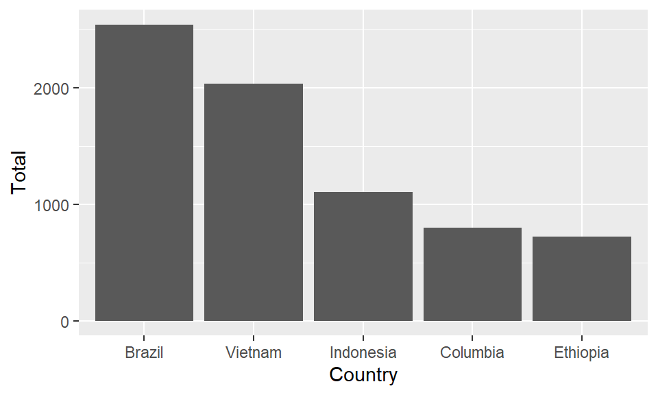

```r
p3
```

### Final Question 5%

- Based on your simulation, who is the top customer and what type of coffee did they purchase? Show scatter plot of top customer total purchases of Arabica or Robusta per month. Use x = month, y = purchases, color = coffee type.

The top customer is Mahima with 670 cups.

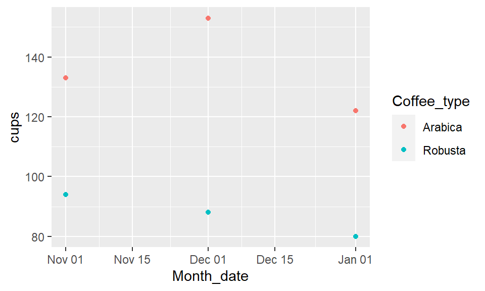

```r
p4
```